# Small Test Spousal Shocks Vectorized Bisection Solve for Exact Savings Choices

[Fan Wang](https://fanwangecon.github.io/)

2020-08-07

# 1 Small Test Exact Solution Spousal Shocks

This is the example vignette for function: [**snw_vfi_main_bisec_vec**](https://github.com/FanWangEcon/PrjOptiSNW/tree/master/PrjOptiSNW/svalpol/snw_vfi_main_bisec_vec.m) from the [**PrjOptiSNW Package**](https://fanwangecon.github.io/PrjOptiSNW/)**.** This function solves for policy function with vectorized bisection. Small Solution Analysis, husband 5 shocks, wife 3 shocks.

## 1.1 Test SNW_VFI_MAIN Defaults Small

Call the function with default parameters.

```
mp_param = snw_mp_param('default_small53');
[V_VFI,ap_VFI,cons_VFI,mp_valpol_more] = snw_vfi_main_bisec_vec(mp_param);

SNW_VFI_MAIN_BISEC_VEC: Finished Age Group:18 of 17, time-this-age:0.10593
SNW_VFI_MAIN_BISEC_VEC: Finished Age Group:17 of 17, time-this-age:0.086471
SNW_VFI_MAIN_BISEC_VEC: Finished Age Group:16 of 17, time-this-age:0.079532
SNW_VFI_MAIN_BISEC_VEC: Finished Age Group:15 of 17, time-this-age:0.095977
SNW_VFI_MAIN_BISEC_VEC: Finished Age Group:14 of 17, time-this-age:0.081549
SNW_VFI_MAIN_BISEC_VEC: Finished Age Group:13 of 17, time-this-age:0.08703
SNW_VFI_MAIN_BISEC_VEC: Finished Age Group:12 of 17, time-this-age:0.089059
SNW_VFI_MAIN_BISEC_VEC: Finished Age Group:11 of 17, time-this-age:0.094402
SNW_VFI_MAIN_BISEC_VEC: Finished Age Group:10 of 17, time-this-age:0.10011
SNW_VFI_MAIN_BISEC_VEC: Finished Age Group:9 of 17, time-this-age:0.093424
SNW_VFI_MAIN_BISEC_VEC: Finished Age Group:8 of 17, time-this-age:0.095447
SNW_VFI_MAIN_BISEC_VEC: Finished Age Group:7 of 17, time-this-age:0.10832
SNW_VFI_MAIN_BISEC_VEC: Finished Age Group:6 of 17, time-this-age:0.089896
SNW_VFI_MAIN_BISEC_VEC: Finished Age Group:5 of 17, time-this-age:0.09249
SNW_VFI_MAIN_BISEC_VEC: Finished Age Group:4 of 17, time-this-age:0.094699
SNW_VFI_MAIN_BISEC_VEC: Finished Age Group:3 of 17, time-this-age:0.087703
SNW_VFI_MAIN_BISEC_VEC: Finished Age Group:2 of 17, time-this-age:0.0939
SNW_VFI_MAIN_BISEC_VEC: Finished Age Group:1 of 17, time-this-age:0.087152
Completed SNW_VFI_MAIN_BISEC_VEC;SNW_MP_PARAM=default_small53;SNW_MP_CONTROL=default_base;time=1.7157
```

## 1.2 Small Param Results Define Frames

Define the matrix dimensions names and dimension vector values. Policy and Value Functions share the same ND dimensional structure.

```
% Grids:
age_grid = [19, 22:5:97, 100];
agrid = mp_param('agrid')';
eta_H_grid = mp_param('eta_H_grid')';
eta_S_grid = mp_param('eta_S_grid')';
ar_st_eta_HS_grid = string(cellstr([num2str(eta_H_grid', 'hz=%3.2f;'), num2str(eta_S_grid', 'wz=%3.2f')]));
edu_grid = [0,1];
marry_grid = [0,1];
kids_grid = (1:1:mp_param('n_kidsgrid'))';
% NaN(n_jgrid,n_agrid,n_etagrid,n_educgrid,n_marriedgrid,n_kidsgrid);
cl_mp_datasetdesc = {};
cl_mp_datasetdesc{1} = containers.Map({'name', 'labval'}, {'age', age_grid});
cl_mp_datasetdesc{2} = containers.Map({'name', 'labval'}, {'savings', agrid});
cl_mp_datasetdesc{3} = containers.Map({'name', 'labval'}, {'eta', 1:length(eta_H_grid)});
cl_mp_datasetdesc{4} = containers.Map({'name', 'labval'}, {'edu', edu_grid});
cl_mp_datasetdesc{5} = containers.Map({'name', 'labval'}, {'marry', marry_grid});
cl_mp_datasetdesc{6} = containers.Map({'name', 'labval'}, {'kids', kids_grid});
```

## 1.3 Analyze Savings and Shocks

First, analyze Savings Levels and Shocks, Aggregate Over All Others, and do various other calculations.

```
% Generate some Data
mp_support_graph = containers.Map('KeyType', 'char', 'ValueType', 'any');
mp_support_graph('cl_st_xtitle') = {'Savings States, a'};
mp_support_graph('st_legend_loc') = 'best';
mp_support_graph('bl_graph_logy') = true; % do not log
mp_support_graph('it_legend_select') = 9; % how many shock legends to show
mp_support_graph('cl_colors') = 'jet';
```

MEAN(VAL(A,Z)), MEAN(AP(A,Z)), MEAN(C(A,Z))

Tabulate value and policies along savings and shocks:

```
% Set
% NaN(n_jgrid,n_agrid,n_etagrid,n_educgrid,n_marriedgrid,n_kidsgrid);
ar_permute = [1,4,5,6,3,2];
% Value Function
tb_az_v = ff_summ_nd_array("MEAN(VAL(A,Z))", V_VFI, true, ["mean"], 4, 1, cl_mp_datasetdesc, ar_permute);

xxx  MEAN(VAL(A,Z))  xxxxxxxxxxxxxxxxxxxxxxxxxxx
    group     savings     mean_eta_1    mean_eta_2    mean_eta_3    mean_eta_4    mean_eta_5    mean_eta_6    mean_eta_7    mean_eta_8    mean_eta_9    mean_eta_10    mean_eta_11    mean_eta_12    mean_eta_13    mean_eta_14    mean_eta_15
    _____    _________    __________    __________    __________    __________    __________    __________    __________    __________    __________    ___________    ___________    ___________    ___________    ___________    ___________

      1              0      -24.423       -14.383       -9.0838       -6.1681       -4.6368        -21.16       -12.873       -8.1373       -5.3766       -3.8904        -16.593        -9.8032        -6.1944        -4.1246         -2.992
      2      0.0097656      -23.655       -14.141       -8.9428       -6.0477        -4.521       -20.721       -12.725       -8.0508       -5.3059       -3.8237        -16.217        -9.6854        -6.1244        -4.0657        -2.9359
      3       0.078125      -20.274       -12.864       -8.2087        -5.441       -3.9447       -18.597       -11.897       -7.5808       -4.9362       -3.4813        -14.463        -9.0428        -5.7563        -3.7684        -2.6574
      4        0.26367      -16.052       -10.951       -7.1333        -4.627       -3.2033       -15.258       -10.427       -6.7883       -4.3683       -2.9802        -11.797        -7.9418        -5.1698        -3.3421        -2.2775
      5          0.625      -12.169       -8.9647       -6.0525        -3.918       -2.6128       -11.753         -8.67       -5.8499       -3.7794       -2.5033        -9.0813        -6.6522        -4.4995        -2.9252        -1.9394
```

[output cut: 86 more lines]

Graph Mean Values:

```
mp_support_graph('cl_st_graph_title') = {'MEAN(value(a,z)), a=x, z=color'};
mp_support_graph('cl_st_ytitle') = {'MEAN(value(a,z))'};
ff_graph_grid((tb_az_v{1:end, 3:end})', ar_st_eta_HS_grid, agrid, mp_support_graph);
```

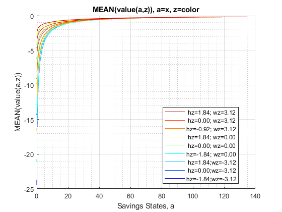

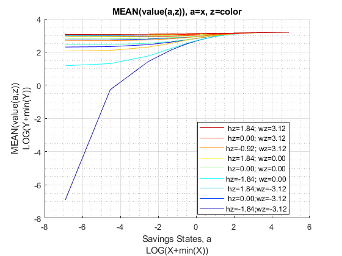

Graph Mean Savings Choices:

```
mp_support_graph('cl_st_graph_title') = {'MEAN(APRIME(a,z)), a=x, z=color'};
mp_support_graph('cl_st_ytitle') = {'MEAN(APRIME(a,z))'};
ff_graph_grid((tb_az_ap{1:end, 3:end})', ar_st_eta_HS_grid, agrid, mp_support_graph);
```

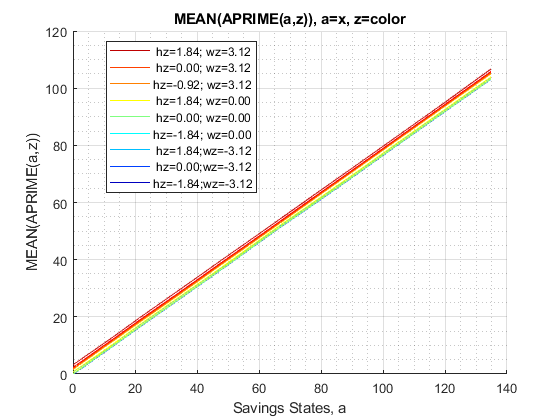

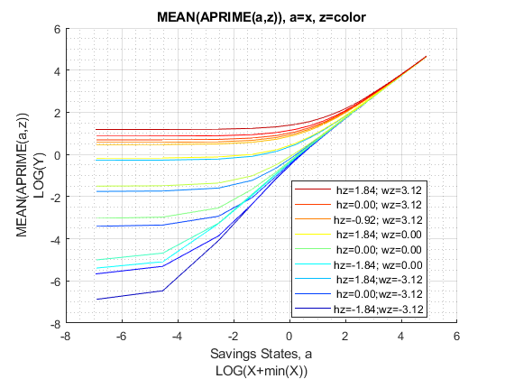

Graph Mean Consumption:

```
mp_support_graph('cl_st_graph_title') = {'MEAN(C(a,z)), a=x, z=color'};
mp_support_graph('cl_st_ytitle') = {'MEAN(C(a,z))'};
ff_graph_grid((tb_az_c{1:end, 3:end})', ar_st_eta_HS_grid, agrid, mp_support_graph);
```

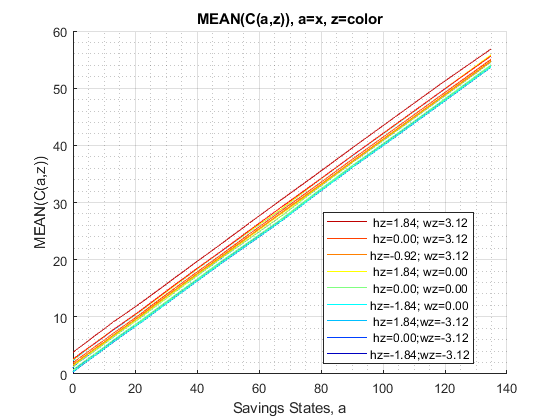

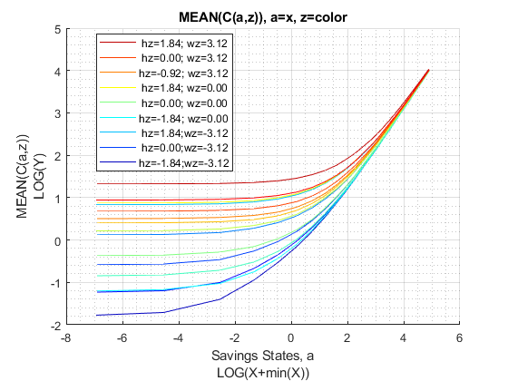

## 1.4 Analyze Kids and Marriage and Age

Aggregating over education, savings, and shocks, what are the differential effects of Marriage and Age.

```
% Generate some Data
mp_support_graph = containers.Map('KeyType', 'char', 'ValueType', 'any');
ar_row_grid = ["k0M0", "K1M0", "K2M0", "k0M1", "K1M1", "K2M1"];
mp_support_graph('cl_st_xtitle') = {'Age'};
mp_support_graph('st_legend_loc') = 'best';
mp_support_graph('bl_graph_logy') = true; % do not log
mp_support_graph('st_rounding') = '6.2f'; % format shock legend
mp_support_graph('cl_scatter_shapes') = { 'o', 'd' ,'s', 'o', 'd', 's'};
mp_support_graph('cl_colors') = {'red', 'red', 'red', 'blue', 'blue', 'blue'};
```

MEAN(VAL(KM,J)), MEAN(AP(KM,J)), MEAN(C(KM,J))

Tabulate value and policies:

```
% Set
% NaN(n_jgrid,n_agrid,n_etagrid,n_educgrid,n_marriedgrid,n_kidsgrid);
ar_permute = [2,3,4,1,6,5];
% Value Function
tb_az_v = ff_summ_nd_array("MEAN(VAL(KM,J))", V_VFI, true, ["mean"], 3, 1, cl_mp_datasetdesc, ar_permute);

xxx  MEAN(VAL(KM,J))  xxxxxxxxxxxxxxxxxxxxxxxxxxx
    group    kids    marry    mean_age_19    mean_age_22    mean_age_27    mean_age_32    mean_age_37    mean_age_42    mean_age_47    mean_age_52    mean_age_57    mean_age_62    mean_age_67    mean_age_72    mean_age_77    mean_age_82    mean_age_87    mean_age_92    mean_age_97    mean_age_100
    _____    ____    _____    ___________    ___________    ___________    ___________    ___________    ___________    ___________    ___________    ___________    ___________    ___________    ___________    ___________    ___________    ___________    ___________    ___________    ____________

      1       1        0        -4.7384        -4.2839        -3.9125        -3.6403        -3.4202        -3.2286        -3.0466        -2.8601        -2.6595        -2.4491        -2.2399        -2.0731        -2.3629        -1.8637        -1.4355         -1.116       -0.89281        -0.68658
      2       2        0        -6.2307        -5.5732         -5.014        -4.5943        -4.2483        -3.9542        -3.6887         -3.434        -3.1782        -2.9257        -2.6801        -2.4926        -2.8794        -2.3137        -1.8328        -1.4683        -1.2096        -0.97097
      3       3        0        -6.9818        -6.3368        -5.7685        -5.3334        -4.9708        -4.6532        -4.3595        -4.0736        -3.7846        -3.4985        -3.2208        -3.0125        -3.5228        -2.8558        -2.2747        -1.8248        -1.5002         -1.1892
      4       1        1        -3.4759        -3.1424        -2.8538        -2.6272        -2.4359        -2.2663        -2.1075        -1.9513        -1.7931        -1.6374        -1.4932        -1.3847        -1.4858        -1.1944       -0.94216       -0.75023       -0.61798        -0.49489
      5       2        1         -4.325        -3.9032        -3.5196        -3.2101        -2.9428        -2.7083        -2.4943        -2.2914        -2.0936        -1.9053        -1.7315        -1.5985        -1.6948        -1.3759        -1.0987       -0.88795       -0.74204        -0.60546
      6       3        1        -4.7282        -4.3225        -3.9432        -3.6317        -3.3597        -3.1133        -2.8816        -2.6564        -2.4324        -2.2154        -2.0111        -1.8459        -1.9256        -1.5703        -1.2589        -1.0197       -0.85265        -0.69356

% Aprime Choice
tb_az_ap = ff_summ_nd_array("MEAN(AP(KM,J))", ap_VFI, true, ["mean"], 3, 1, cl_mp_datasetdesc, ar_permute);

xxx  MEAN(AP(KM,J))  xxxxxxxxxxxxxxxxxxxxxxxxxxx
    group    kids    marry    mean_age_19    mean_age_22    mean_age_27    mean_age_32    mean_age_37    mean_age_42    mean_age_47    mean_age_52    mean_age_57    mean_age_62    mean_age_67    mean_age_72    mean_age_77    mean_age_82    mean_age_87    mean_age_92    mean_age_97    mean_age_100
    _____    ____    _____    ___________    ___________    ___________    ___________    ___________    ___________    ___________    ___________    ___________    ___________    ___________    ___________    ___________    ___________    ___________    ___________    ___________    ____________

      1       1        0        34.931         34.726         34.665         34.554         34.362         34.077         33.682         33.147         32.422           31.5         30.819         29.713         26.817         24.458         21.039         16.761         11.058            0
      2       2        0        34.603         34.334         34.198         33.995         33.692         33.286         32.762         32.089         31.289         30.736         29.885         28.361         25.892         23.172         19.841         15.524         10.196            0
      3       3        0        34.187         33.968         33.877         33.705         33.427         33.033          32.51          31.83          31.11          30.61         29.726         28.203         25.828         23.157         19.895         15.696          10.38            0
      4       1        1        35.713         35.611           35.7         35.727          35.66         35.493         35.215         34.799         34.189         33.405         32.672         31.512         27.898         25.399          21.82         17.365         11.474            0
      5       2        1        35.368         35.246         35.284         35.242         35.101         34.849         34.477         33.956         33.237         32.553         31.755         30.453         27.335         24.621         21.078         16.723         10.908            0
```

[output cut: 15 more lines]

Graph Mean Values:

```
mp_support_graph('cl_st_graph_title') = {'MEAN(value(KM,J)), a=age, z=kids+marry'};
mp_support_graph('cl_st_ytitle') = {'MEAN(value(KM,J))'};
ff_graph_grid((tb_az_v{1:end, 4:end}), ar_row_grid, age_grid, mp_support_graph);
```

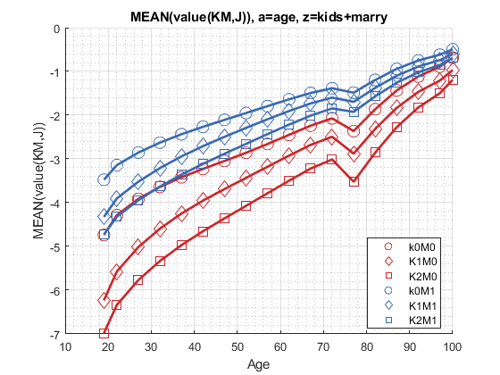

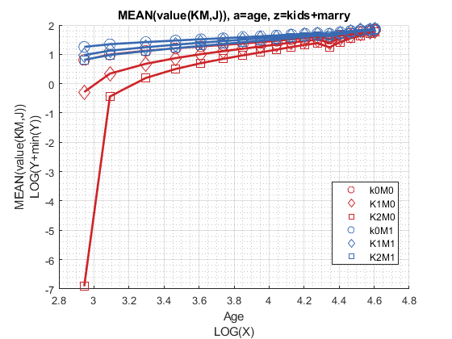

Graph Mean Savings Choices:

```
mp_support_graph('cl_st_graph_title') = {'MEAN(APRIME(KM,J)), a=x, z=color'};
mp_support_graph('cl_st_ytitle') = {'MEAN(APRIME(KM,J))'};
ff_graph_grid((tb_az_ap{1:end, 4:end}), ar_row_grid, age_grid, mp_support_graph);
```

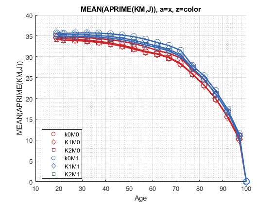

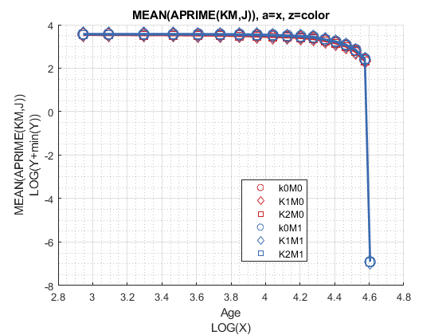

Graph Mean Consumption:

```
mp_support_graph('cl_st_graph_title') = {'MEAN(C(KM,J)), a=x, z=color'};
mp_support_graph('cl_st_ytitle') = {'MEAN(C(KM,J))'};
ff_graph_grid((tb_az_c{1:end, 4:end}), ar_row_grid, age_grid, mp_support_graph);
```

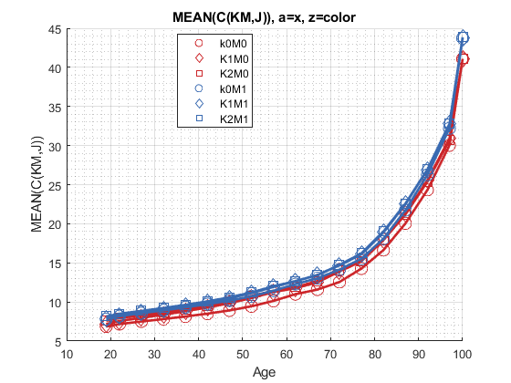

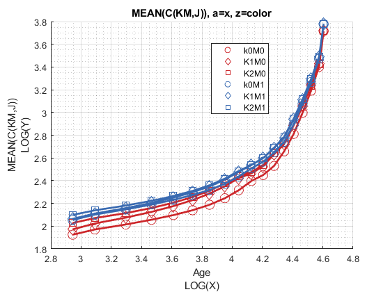

## 1.5 Analyze Education and Marriage and Age

```
% Generate some Data
mp_support_graph = containers.Map('KeyType', 'char', 'ValueType', 'any');
ar_row_grid = ["E0M0", "E1M0", "E0M1", "E1M1"];
mp_support_graph('cl_st_xtitle') = {'Age'};
mp_support_graph('st_legend_loc') = 'best';
mp_support_graph('bl_graph_logy') = true; % do not log
mp_support_graph('st_rounding') = '6.2f'; % format shock legend
mp_support_graph('cl_scatter_shapes') = {'*', 'p', '*','p' };
mp_support_graph('cl_colors') = {'red', 'red', 'blue', 'blue'};
```

MEAN(VAL(EKM,J)), MEAN(AP(EKM,J)), MEAN(C(EKM,J))

Tabulate value and policies:

```
% Set
% NaN(n_jgrid,n_agrid,n_etagrid,n_educgrid,n_marriedgrid,n_kidsgrid);
ar_permute = [2,3,6,1,4,5];
% Value Function
tb_az_v = ff_summ_nd_array("MEAN(VAL(EKM,J))", V_VFI, true, ["mean"], 3, 1, cl_mp_datasetdesc, ar_permute);

xxx  MEAN(VAL(EKM,J))  xxxxxxxxxxxxxxxxxxxxxxxxxxx
    group    edu    marry    mean_age_19    mean_age_22    mean_age_27    mean_age_32    mean_age_37    mean_age_42    mean_age_47    mean_age_52    mean_age_57    mean_age_62    mean_age_67    mean_age_72    mean_age_77    mean_age_82    mean_age_87    mean_age_92    mean_age_97    mean_age_100
    _____    ___    _____    ___________    ___________    ___________    ___________    ___________    ___________    ___________    ___________    ___________    ___________    ___________    ___________    ___________    ___________    ___________    ___________    ___________    ____________

      1       0       0        -6.4015        -5.8666        -5.3879        -4.9966        -4.6557        -4.3525        -4.0711        -3.7972        -3.5191        -3.2399        -2.9631        -2.7398        -3.0999        -2.4877        -1.9609         -1.561        -1.2765         -1.0093
      2       1       0        -5.5658        -4.9294        -4.4088        -4.0487        -3.7705        -3.5382        -3.3254        -3.1146        -2.8958        -2.6757        -2.4641        -2.3123        -2.7435         -2.201        -1.7345        -1.3784        -1.1253        -0.88856
      3       0       1        -4.4764        -4.1029        -3.7581        -3.4622        -3.1968        -2.9557        -2.7306        -2.5141        -2.3006        -2.0946        -1.9015        -1.7476         -1.819         -1.475        -1.1758       -0.94656       -0.78798        -0.63847
      4       1       1        -3.8764        -3.4759        -3.1196        -2.8504        -2.6288        -2.4363        -2.2583        -2.0853        -1.9122        -1.7442        -1.5889        -1.4719        -1.5851        -1.2854         -1.024       -0.82536       -0.68713        -0.55747

% Aprime Choice
tb_az_ap = ff_summ_nd_array("MEAN(AP(EKM,J))", ap_VFI, true, ["mean"], 3, 1, cl_mp_datasetdesc, ar_permute);

xxx  MEAN(AP(EKM,J))  xxxxxxxxxxxxxxxxxxxxxxxxxxx
    group    edu    marry    mean_age_19    mean_age_22    mean_age_27    mean_age_32    mean_age_37    mean_age_42    mean_age_47    mean_age_52    mean_age_57    mean_age_62    mean_age_67    mean_age_72    mean_age_77    mean_age_82    mean_age_87    mean_age_92    mean_age_97    mean_age_100
    _____    ___    _____    ___________    ___________    ___________    ___________    ___________    ___________    ___________    ___________    ___________    ___________    ___________    ___________    ___________    ___________    ___________    ___________    ___________    ____________

      1       0       0        34.682         34.444         34.272         34.048         33.753         33.374         32.888         32.256         31.512         30.851          30.02         28.595          26.17         23.589         20.254         15.987         10.542            0
      2       1       0        34.465         34.241         34.222         34.121         33.901         33.556         33.081         32.455         31.703         31.046         30.267         28.923         26.188         23.603         20.262             16         10.548            0
      3       0       1        35.363         35.234         35.193         35.099         34.934         34.686         34.331         33.831         33.132         32.407         31.616         30.323         27.362         24.751         21.229         16.874         11.069            0
      4       1       1        35.293          35.21          35.37         35.437         35.374         35.174         34.846         34.367         33.703         33.023         32.261         31.015         27.656         24.989         21.429         17.037         11.188            0

% Consumption Choices
tb_az_c = ff_summ_nd_array("MEAN(C(EKM,J))", cons_VFI, true, ["mean"], 3, 1, cl_mp_datasetdesc, ar_permute);

xxx  MEAN(C(EKM,J))  xxxxxxxxxxxxxxxxxxxxxxxxxxx
    group    edu    marry    mean_age_19    mean_age_22    mean_age_27    mean_age_32    mean_age_37    mean_age_42    mean_age_47    mean_age_52    mean_age_57    mean_age_62    mean_age_67    mean_age_72    mean_age_77    mean_age_82    mean_age_87    mean_age_92    mean_age_97    mean_age_100
    _____    ___    _____    ___________    ___________    ___________    ___________    ___________    ___________    ___________    ___________    ___________    ___________    ___________    ___________    ___________    ___________    ___________    ___________    ___________    ____________

      1       0       0        7.1022         7.4087         7.7357         8.0845         8.4713         8.9105          9.427         10.062         10.782         11.389         12.136         13.445           14.9          17.48         20.815         25.082         30.528           41.07
      2       1       0        7.3195         7.7041         8.0988         8.4875         8.8852          9.312         9.8044         10.409         11.116         11.703         12.379         13.565         14.917         17.502         20.843         25.105         30.557          41.105
      3       0       1        7.7587         8.0743         8.4083         8.7618         9.1489         9.5822         10.086         10.701          11.48         12.245         13.031          14.27         15.805         18.483         22.066         26.477         32.333          43.447
      4       1       1         8.134         8.5446         8.9747         9.3891         9.8055         10.248         10.742         11.338         12.087         12.819         13.583         14.752         16.089          18.84         22.478         26.941         32.854          44.099
```

Graph Mean Values:

```
mp_support_graph('cl_st_graph_title') = {'MEAN(value(EM,J)), a=age, z=kids+marry'};
mp_support_graph('cl_st_ytitle') = {'MEAN(value(EM,J))'};
ff_graph_grid((tb_az_v{1:end, 4:end}), ar_row_grid, age_grid, mp_support_graph);
```

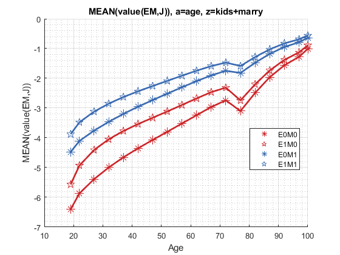

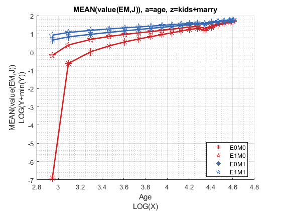

Graph Mean Savings Choices:

```
mp_support_graph('cl_st_graph_title') = {'MEAN(APRIME(EK,J)), a=x, z=color'};
mp_support_graph('cl_st_ytitle') = {'MEAN(APRIME(EK,J))'};
ff_graph_grid((tb_az_ap{1:end, 4:end}), ar_row_grid, age_grid, mp_support_graph);
```

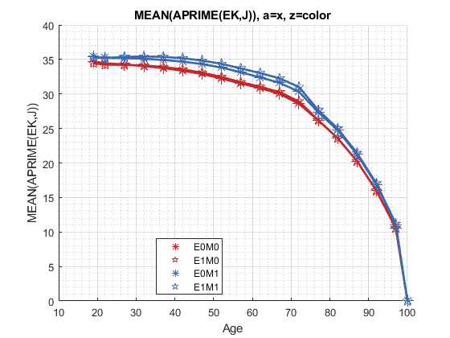

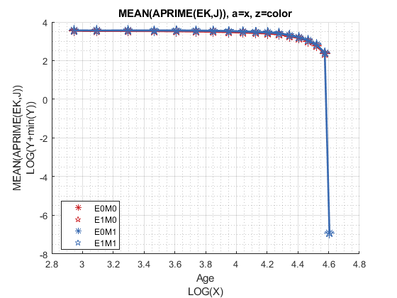

Graph Mean Consumption:

```
mp_support_graph('cl_st_graph_title') = {'MEAN(C(EK,J)), a=x, z=color'};
mp_support_graph('cl_st_ytitle') = {'MEAN(C(EK,J))'};
ff_graph_grid((tb_az_c{1:end, 4:end}), ar_row_grid, age_grid, mp_support_graph);
```

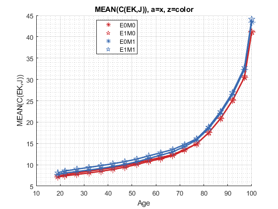

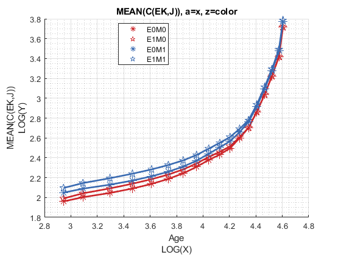